# Chapter 5 homework

## Setup

```r
# If you don't have a package yet, install it once:
# install.packages(c("tidyverse", "here", "broom", "pwr", "psych"))

library(tidyverse)
library(here)
library(broom)
library(pwr)
library(psych)
options(scipen = 999)

knitr::opts_chunk$set(echo = TRUE, message = FALSE, warning = FALSE)
```

## General notes on the model-comparison workflow

For most questions below, you will compare:

- **Model C (constrained / null model)**: a model where the intercept is fixed (often to 0 or to a known/reference value).
- **Model A (augmented model)**: a model where the intercept is estimated from the data.

For a one-parameter intercept-only Model A,

$$\text{Model A: } Y_i = b_0 + \varepsilon_i$$

and for a fixed-intercept Model C (often $b_0$ fixed to some value $c$),

$$\text{Model C: } Y_i = c + \varepsilon_i.$$

The key quantities:

- $\mathrm{SSE}$ is sum of squared errors.
- $\mathrm{PRE} = \dfrac{\mathrm{SSE}_C - \mathrm{SSE}_A}{\mathrm{SSE}_C}$.
- For a one-parameter comparison (typically $P_A - P_C = 1$), the usual model-comparison $F$ statistic is:

$$F = \frac{(\mathrm{SSE}_C - \mathrm{SSE}_A)/(P_A - P_C)}{\mathrm{SSE}_A/(n - P_A)}.$$

# Part A: Hand-calculation practice (small, self-contained datasets)

## A1. Schizophrenia age of onset

Assume the mean age of onset of schizophrenia in a sample of $n=50$ persons was $\bar{y} = 21.5$ years and the variance was $s^2 = 2.5$ (years$^2$).

1. Specify the model that uses the mean to describe the data (Model A), in both words and in equation form.

   Words: The average individual in the sample will onset schizophrenia at 21.5 years of age.

   Equation: $Y_i = b_0 + \varepsilon_i$ or $Y_i = 21.5 + \varepsilon_i$
2. What is the $\mathrm{SSE}$ for this model?

*(Use the definitional relationships between variance, sums of squares, and SSE for an intercept-only model.)*

```r
sse <- 2.5^2 * (50 - 1)
sse
```

```
[1] 306.25
```

## A2. Multiculturalism vs. colorblindness (paired data)

Ryan, Hunt, Weible, Peterson, and Casas (2007) investigated Americans’ interethnic ideologies. They asked college students to indicate the extent to which they believed that multiculturalism and colorblind ideologies would improve interethnic relations in the U.S.

Assume you have data for 10 Black participants:

| Subjid | MC | CB | Diff (MC − CB) |
| --- | --- | --- | --- |
| 1 | 5.0 | 4.0 | 1.0 |
| 2 | 4.0 | 3.5 | 0.5 |
| 3 | 6.0 | 4.0 | 2.0 |
| 4 | 6.0 | 6.0 | 0.0 |
| 5 | 5.0 | 4.5 | 0.5 |
| 6 | 4.5 | 5.0 | -0.5 |
| 7 | 5.0 | 3.0 | 2.0 |
| 8 | 6.5 | 4.5 | 2.0 |
| 9 | 7.0 | 5.0 | 2.0 |
| 10 | 6.5 | 3.0 | 3.5 |

### A2a. By hand

1. Compute **by hand** the mean, variance, and standard deviation of the difference variable. Use definitional formulas.

   $mean = 1.3$, $variance = 1.4\bar5$, $sd \approx 1.2$
2. Compute $\mathrm{SSE}_C$ for the simple model that predicts no difference (i.e., that the difference is 0). This is Model C.

   $\mathrm{SSE}_C = 30$
3. Compute $\mathrm{SSE}_A$ for the simple model that best describes the differences based on the data (Model A).

   $\mathrm{SSE}_A = 13.1$
4. Compute PRE and $F$.

Null hypothesis: there is no difference between how much individuals think that multicultural ideologies improves on colorblindness ideologies in improving ethnic relations in the US

1. Indicate whether you would reject or fail to reject Model C / the null hypothesis.

1. Write up your findings in journal style.

In this sample, college students believe that multicultural ideologies will improve ethnic relations in the US more than colorblindness ideologies.

### A2b. In R (reproducing your values)

Recreate the analysis in R and verify the quantities above (mean, variance/SD, $\mathrm{SSE}_C$, $\mathrm{SSE}_A$, PRE, $F$, and $p$).

```r
df <- tibble(
  subjid = c(1:10),
  MC = c(5.0, 4.0, 6.0, 6.0, 5.0, 4.5, 5.0, 6.5, 7.0, 6.5),
  CB = c(4.0, 3.5, 4.0, 6.0, 4.5, 5.0, 3.0, 4.5, 5.0, 3.0),
  diff_MC_CB = MC - CB
)
n <- nrow(df)

mean_df <- mean(df$diff_MC_CB)
mean_df
```

```
[1] 1.3
```

```r
var_df <- var(df$diff_MC_CB)
var_df
```

```
[1] 1.455556
```

```r
sd_df <- sd(df$diff_MC_CB)
sd_df
```

```
[1] 1.206464
```

```r
sum((df$diff_MC_CB - 1.3)^2)
```

```
[1] 13.1
```

```r
model_c <- lm(diff_MC_CB ~ 0, data = df)
sse_c <- deviance(model_c)
sse_c
```

```
[1] 30
```

```r
model_a <- lm(diff_MC_CB ~ 1, data = df)
sse_a <- deviance(model_a)
sse_a
```

```
[1] 13.1
```

```r
pre <- (sse_c - sse_a) / sse_c
pre
```

```
[1] 0.5633333
```

```r
f_star <- pre / ((1 - pre) / (n - 1))
f_star
```

```
[1] 11.61069
```

### A2c. Confidence interval

Construct a 95% confidence interval for the multiculturalism − colorblindness difference score in this sample.

```r
f_crit <- qf(0.95, 1, 9)
bounds <- sqrt((f_crit * var_df) / n)
lower_bound <- mean_df - bounds
lower_bound
```

```
[1] 0.4369476
```

```r
upper_bound <- mean_df + bounds
upper_bound
```

```
[1] 2.163052
```

### A2d. Power planning with `pwr`

A researcher wants to replicate the finding with a new sample of 10 participants.

1. Use results from this sample and the `pwr` package to estimate the number of participants needed to replicate your observed effect (at $\alpha = .05$).
2. Use the same package to estimate the number of participants needed to detect a **medium** effect size (according to Cohen’s very arbitrary definition…).

```r
d <- 2 * (pre / sqrt(1 - pre))

pwr.t.test(d = d, sig.level = 0.05, power = 0.8, type = "one.sample")
```

```
     One-sample t test power calculation

              n = 4.928718
              d = 1.704984
      sig.level = 0.05
          power = 0.8
    alternative = two.sided
```

```r
med_cohen <- cohen.ES(test = "t", size = "medium")
pwr.t.test(d = 0.5, sig.level = 0.06, power = 0.8, type = "one.sample")
```

```
     One-sample t test power calculation

              n = 31.46698
              d = 0.5
      sig.level = 0.06
          power = 0.8
    alternative = two.sided
```

## A3. Gym BMI (one-sample mean test)

A researcher wonders whether people who go to the gym in January have above-normal BMIs, that is, above 24.9 (upper level of “normal,” according to the CDC). She obtains the BMI scores below for a randomly selected group of 10 gym users:

| Participant | BMI |
| --- | --- |
| 1 | 24.0 |
| 2 | 27.0 |
| 3 | 25.0 |
| 4 | 27.0 |
| 5 | 27.0 |
| 6 | 23.0 |
| 7 | 22.0 |
| 8 | 30.0 |
| 9 | 26.0 |
| 10 | 29.0 |

1. Specify Models C and A and the null hypothesis for this statistical test. What is this test commonly called?

Let $\Delta_i = BMI - 24.9$

Model C: $\Delta_i = 0 + \varepsilon_i.$

Model A: $\Delta_i = b_0 + \varepsilon_i$

Null hypothesis: There is no difference between BMI’s of individuals who go to the gym in January and the average population BMI.

1. Conduct the analysis **by hand**.

   $\mu_\Delta = 1.1$

   $\mathrm{SSE}_C = 70.1$

   $\mathrm{SSE}_A = 58$

   $PRE = 0.17$

   $F \approx 1.88$
1. Conduct the analysis in R.
2. Provide a statistical conclusion.

Do not reject the null hypothesis because the F critical value > F*.

1. Write up your findings in journal style.

We do not reject the null hypothesis that there is no difference in BMI between individuals who work out in January compared to the general population.

```r
df <- tibble(
  participant = c(1:10),
  bmi = c(24.0, 27.0, 25.0, 27.0, 27.0, 23.0, 22.0, 30.0, 26.0, 29.0),
  diff_BMI = bmi - 24.9
)

n <- nrow(df)

mean_df <- mean(df$diff_BMI)
mean_df
```

```
[1] 1.1
```

```r
model_c <- lm(diff_BMI ~ 0, data = df)
sse_c <- deviance(model_c)
sse_c
```

```
[1] 70.1
```

```r
model_a <- lm(diff_BMI ~ 1, data = df)
sse_a <- deviance(model_a)
sse_a
```

```
[1] 58
```

```r
pre <- (sse_c - sse_a) / sse_c
pre
```

```
[1] 0.1726106
```

```r
f_star <- pre / ((1 - pre) / (n - 1))
f_star
```

```
[1] 1.877586
```

```r
f_star > qf(0.95, 1, 9)
```

```
[1] FALSE
```

# Part B: Fitness dataset (model comparison, confidence intervals, power)

## B0. Read the data

Read in the `fitness.csv` dataset from the course project `data/` folder.

```r
fitness <- read_csv(here("data", "fitness.csv"))
```

## B1. Resting pulse vs. “normal” (72 bpm)

The variable `RSTPULSE` contains resting pulse rate for each participant in the fitness study. The normal pulse rate for men is 72.

### B1a. 95% CI for $b_0$ in Model A

Construct a 95% confidence interval for $b_0$ in Model A.

- Do this **by hand** using a critical value (e.g., $t_{\alpha/2, \, df}$), and then confirm with R.
- Make note of what in R output corresponds to your hand calculation.

$CI = 53.74 \pm 3.04$

For reference, the by-hand CI for an intercept estimate is:

$$\hat{b}_0 \pm t_{\alpha/2, \, df} \cdot SE(\hat{b}_0).$$

```r
f_crit <- qf(0.95, 1, 30)
mean_rstpulse <- mean(fitness$RSTPULSE)
var_rstpulse <- var(fitness$RSTPULSE)
n <- nrow(fitness)
bounds <- sqrt((f_crit * var_rstpulse) / n)
lower_bound <- mean_rstpulse - bounds
lower_bound
```

```
[1] 50.69951
```

```r
upper_bound <- mean_rstpulse + bounds
upper_bound
```

```
[1] 56.78436
```

### B1b. Journal-style summary

Write a complete summary:

1. briefly explain the data;

The data is different health/fitness variables of 31 individuals.

1. set up the analysis (describe the comparison without using “Model A/C” language if you prefer);

Is this group of individuals in this dataset resting pulse normal?

1. report mean (and SD), test statistic ($t$ or $F$), PRE, $p$, and the confidence interval; and

```r
mean_rstpulse
```

```
[1] 53.74194
```

```r
sd_rstpulse <- sd(fitness$RSTPULSE)
sd_rstpulse
```

```
[1] 8.294447
```

```r
fitness <- fitness |>
  mutate(diff_rstpulse = RSTPULSE - 72)

model_c <- lm(diff_rstpulse ~ 0, data = fitness)
sse_c <- deviance(model_c)
sse_c
```

```
[1] 12398
```

```r
model_a <- lm(diff_rstpulse ~ 1, data = fitness)
sse_a <- deviance(model_a)
sse_a
```

```
[1] 2063.935
```

```r
pre <- (sse_c - sse_a) / sse_c
pre
```

```
[1] 0.8335267
```

```r
f_star <- pre / ((1 - pre) / (n - 1))
f_star
```

```
[1] 150.2091
```

```r
upper_bound
```

```
[1] 56.78436
```

```r
lower_bound
```

```
[1] 50.69951
```

1. state statistical and substantive conclusions.

No, this group has a statistically significant difference in resting pulse from the normal rate.

### B1c. Estimate of true PRE

If you wanted to replicate this study, what would be your best guess for the *true* value of PRE?

```r
calc_null_pre <- function() {
  sims <- tibble(diff_rstpulse = rnorm(31, 0, sqrt(var_rstpulse)))
  m0 <- lm(diff_rstpulse ~ 0, data = sims)
  m1 <- lm(diff_rstpulse ~ 1, data = sims)
  pre <- (deviance(m0) - deviance(m1)) / deviance(m0)
  return(pre)
}

null_sims <- tibble(sim_number = 1:1000) |>
  rowwise() |>
  mutate(pre = calc_null_pre())

summary(null_sims$pre)
```

```
       Min.     1st Qu.      Median        Mean     3rd Qu.        Max.
0.000000255 0.003157176 0.015391417 0.032353060 0.043026457 0.267550620
```

```r
true_pre_guess <- mean(null_sims$pre)
```

True PRE is likely very small, around 0.03 based on bootstrap sampling

### B1d. Power for a replication at the same $n$

Given your estimate of true PRE, if you replicated with the same sample size, what would be your power to detect the effect? Use `pwr.f2.test()`.

A common translation between PRE and Cohen’s $f^2$ for this model-comparison setup is:

$$f^2 = \frac{\mathrm{PRE}}{1-\mathrm{PRE}}.$$

```r
f2 <- true_pre_guess / (1 - true_pre_guess)
pwr.f2.test(1, 30, f2 = f2, sig.level = 0.05)
```

```
     Multiple regression power calculation

              u = 1
              v = 30
             f2 = 0.03343478
      sig.level = 0.05
          power = 0.1704451
```

## B2. Did running increase pulse rate? (within-person change)

Using the same dataset, compare resting pulse (`RSTPULSE`) to post-run pulse (`RUNPULSE`). Did running increase pulse rate?

Hint: create a new variable such as:

$$\text{change} = \text{RUNPULSE} - \text{RSTPULSE}.$$

### B2a. 95% CI for $b_0$ in Model A

Construct a 95% CI for $b_0$ in your Model A for the change score. Do it by hand, then confirm with R.

```r
fitness <- fitness |>
  mutate(change = RUNPULSE - RSTPULSE)

n <- nrow(fitness)
mean_change <- mean(fitness$change)
mean_change
```

```
[1] 115.9032
```

```r
var_change <- var(fitness$change)
var_change
```

```
[1] 119.8237
```

```r
f_crit <- qf(0.95, 1, 30)

n <- nrow(fitness)
bounds <- sqrt((f_crit * var_change) / n)
lower_bound <- mean_change - bounds
lower_bound
```

```
[1] 111.8881
```

```r
upper_bound <- mean_change + bounds
upper_bound
```

```
[1] 119.9184
```

### B2b. Estimate of true PRE

If you wanted to replicate this study, what would be your best guess for the true value of PRE?

```r
calc_null_pre <- function() {
  sims <- tibble(change = rnorm(31, 0, sqrt(var_change)))
  m0 <- lm(change ~ 0, data = sims)
  m1 <- lm(change ~ 1, data = sims)
  pre <- (deviance(m0) - deviance(m1)) / deviance(m0)
  return(pre)
}

null_sims <- tibble(sim_number = 1:1000) |>
  rowwise() |>
  mutate(pre = calc_null_pre())

summary(null_sims$pre)
```

```
     Min.   1st Qu.    Median      Mean   3rd Qu.      Max.
0.0000003 0.0031015 0.0155208 0.0333437 0.0447348 0.3914256
```

```r
true_pre_guess <- mean(null_sims$pre)
true_pre_guess
```

```
[1] 0.03334371
```

### B2c. Required effect size for power = .80 at n = 100

How big would true PRE need to be to yield power = .80 in a future study with $n=100$ participants? Use `pwr.f2.test()`.

```r
power_test <- pwr.f2.test(1, 99, sig.level = 0.05, power = 0.8)
f2 <- power_test$f2

true_pre <- f2 / (1 + f2)
true_pre
```

```
[1] 0.07343774
```

True PRE would need to be 0.07 to yield power = 0.8 with n = 100 participants

## B3. Oral contraceptives and systolic blood pressure (Rosner example)

Ten women are studied to determine if oral contraceptives increase systolic blood pressure (mm Hg). Baseline blood pressure is measured before and then again several months after oral contraceptives are started. The following **changes** in systolic blood pressure are observed:

13, 3, -1, 9, 7, 7, 6, 4, -2, 2

A summary table (from SAS) reports:

| Mean | Std Dev | USS | CSS | T | Prob > |
| --- | --- | --- | --- | --- | --- |
| 4.8000000 | 4.5655716 | 418.0000000 | 187.6000000 | 3.3246511 | 0.0089 |

Here, **USS** (“uncorrected sum of squares”) represents squared error around the model $Y_i = 0 + \varepsilon_i$ (i.e., Model C with intercept fixed at 0). **CSS** (“corrected sums of squares”) represents squared error around u (Model A with estimated intercept).

### B3a. Interpret the output using model comparison

Use this output to determine whether blood pressure significantly increased after oral contraceptives were begun.

1. Specify Models A & C (equations are encouraged).

   Model C: $Y_i = 0 + \varepsilon_i$

   Model A: $Y_i = b_0 + \varepsilon_i$
2. Specify the null hypothesis.

   Null hypothesis is that oral contraceptives do not increase systolic blood pressure.
3. Calculate PRE and $F$.

```r
n <- 10

sse_c <- 418
sse_a <- 187.6

pre <- (sse_c - sse_a) / sse_c
pre
```

```
[1] 0.5511962
```

```r
f_star <- pre / ((1 - pre) / (n - 1))
f_star
```

```
[1] 11.0533
```

```r
f_crit <- qf(0.99, 1, 9)
f_star > f_crit
```

```
[1] TRUE
```

1. State your statistical and substantive one-sentence conclusions.

Reject the null hypothesis because $F$ is greater than the critical value of F at 99% confidence interval. Therefore, using oral contraceptives does increase systolic blood pressure.

### B3b. Estimate of true PRE

If you wanted to replicate this study, what would be your best guess for the true value of PRE?

```r
calc_null_pre <- function() {
  sims <- tibble(bp = rnorm(10, 0, 4.5655716))
  m0 <- lm(bp ~ 0, data = sims)
  m1 <- lm(bp ~ 1, data = sims)
  pre <- (deviance(m0) - deviance(m1)) / deviance(m0)
  return(pre)
}

null_sims <- tibble(sim_number = 1:1000) |>
  rowwise() |>
  mutate(pre = calc_null_pre())

summary(null_sims$pre)
```

```
      Min.    1st Qu.     Median       Mean    3rd Qu.       Max.
0.00000003 0.00993733 0.05540571 0.10432101 0.14664194 0.78077097
```

```r
true_pre_guess <- mean(null_sims$pre)
true_pre_guess
```

```
[1] 0.104321
```

### B3c. Sample size for power targets

What sample size would you need to achieve power = .80? What sample size would you need to achieve power = .90? Use `pwr.f2.test()`.

```r
f2 = true_pre_guess / (1 - true_pre_guess)
power_test_80 <- pwr.f2.test(u = 1, f2 = f2, sig.level = 0.05, power = 0.8)
round(power_test_80$v + 1, 0)
```

```
[1] 68
```

```r
power_test_90 <- pwr.f2.test(u = 1, f2 = f2, sig.level = 0.05, power = 0.9)
round(power_test_90$v + 1, 0)
```

```
[1] 91
```

## B4. Power and design choices (GPA example)

In a particular year, a graduate program admitted 24 new students. The admissions committee wants to interpret the students’ first-year GPA.

### B4a. Approximate power for a “moderate” effect

Graduate students in this program are required to maintain a 3.0 average. The committee plans to compare:

- Model C: GPA fixed at 3.0
- Model A: GPA estimated as the students’ mean

If the true difference corresponds to what the text refers to as a “moderate” effect in the social sciences, what are the chances that the committee will correctly conclude Model A is better than Model C if they use $\alpha = .05$?

1. Calculate approximate power using the book approach.
2. Verify using `pwr` (it will not match exactly, but should be close).

```r
med_cohen <- cohen.ES(test = "t", size = "medium")
d <- med_cohen$effect.size
power_test <- pwr.t.test(n = 24, d = 0.5, sig.level = 0.05, type = "one.sample")
power_test$power
```

```
[1] 0.6503918
```

### B4b. Two ways to increase power without increasing n

Given that they cannot admit additional students, state two things they could do to increase power.

1. They could increase alpha, i.e. the probability of a type 1 error
2. They could increase the size of the effect, i.e. only accept model A if the effect is large

### B4c. Try-out question: setting up a conditional model comparison

The committee wants to know whether GRE-Verbal, GRE-Math, and undergraduate GPA are useful predictors of first-year GPA.

We have not yet learned how to *test* these conditional models, but set up the comparison:

- Model C: predicts the mean
- Model A: predicts GPA conditionally using all 3 predictors

Specify both models and indicate $n - P_A$ and $P_A - P_C$ for this comparison.

Model C: $Y_i = b_0 + \varepsilon_i$

Model A: $Y_i = b_0 + GRE_V + GRE_M + GPA_U + \varepsilon_i$

$P_A - P_C = 4 - 1 = 3$

$n - P_A = 24 - 4 = 20$

# Part C: Your own data (leave code blocks empty)

These questions refer to the model comparison you tested previously using your own dataset.

```r
gss2024 <- readRDS(here("data", "gss2024.rds"))

df <- gss2024 |>
  select(eqwlth) |>
  drop_na() |>
  haven::zap_labels()

df <- df |>
  mutate(eqwlth_dev = eqwlth - 4)

mean_df <- mean(df$eqwlth)

model_c <- lm(eqwlth_dev ~ 0, data = df)
model_a <- lm(eqwlth_dev ~ 1, data = df)

observed_pre <- (deviance(model_c) - deviance(model_a)) / deviance(model_c)
observed_pre
```

```
[1] 0.07094055
```

## C1. Confidence interval for $b_0$

Identify the 95% confidence interval for $b_0$ in Model A. Explain what this interval represents.

```r
f_crit <- qf(0.95, 1, 2160)
var_df <- var(df$eqwlth)
sd_df <- sd(df$eqwlth)

n <- nrow(df)
bounds <- sqrt((f_crit * var_df) / n)
lower_bound <- mean_df - bounds
lower_bound
```

```
[1] 3.3071
```

```r
upper_bound <- mean_df + bounds
upper_bound
```

```
[1] 3.490679
```

## C2. Journal-style summary

Write a complete journal-style summary for your data.

I chose the variable eqwlth, which is: ‘Should govt reduce income difference?’ The unit of analyis are the individuals taking the survey. There are 2161 individuals who answered the question for this variable in 2024. The dependent is the extent to which the individuals agree with this statement, between 1 and 7, where 1 is the government should reduce income differences, and 7 is the government should not concern itself with reducing income differences. It is measured on an ordinal scale, with individuals selecting the extent to which they lean one way or the other on the topic. It’s distribution is higher at 1, normally distributed between 2 and 6, and higher again at 7.

## C3. Estimate of true PRE

If you wanted to replicate this study, what would be your best guess for the true value of PRE?

```r
calc_null_pre <- function() {
  sims <- tibble(eqwlth = rnorm(2161, 0, sd_df))
  m0 <- lm(eqwlth ~ 0, data = sims)
  m1 <- lm(eqwlth ~ 1, data = sims)
  pre <- (deviance(m0) - deviance(m1)) / deviance(m0)
  return(pre)
}

null_sims <- tibble(sim_number = 1:1000) |>
  rowwise() |>
  mutate(pre = calc_null_pre())

summary(null_sims$pre)
```

```
        Min.      1st Qu.       Median         Mean      3rd Qu.         Max.
0.0000000013 0.0000397564 0.0002154749 0.0004420273 0.0005876146 0.0062805678
```

```r
true_pre_guess <- mean(null_sims$pre)
true_pre_guess
```

```
[1] 0.0004420273
```

My best true pre guess is 0.0005.

## C4. Sample size for power = .80

Given your estimate of true PRE, what sample size would you need to achieve power = .80? Use `pwr.f2.test()`.

```r
f2 <- true_pre_guess / (1 - true_pre_guess)
power_test <- pwr.f2.test(u = 1, v = 2160, f2 = f2, sig.level = 0.05)
power_test$power
```

```
[1] 0.1645569
```

## C5. Sketch the PRE distributions

Draw a chart that shows the distribution of PRE under both the $H_0$ and $H_1$ hypotheses. Label $\alpha$, $\beta$, power, and the surprise point.

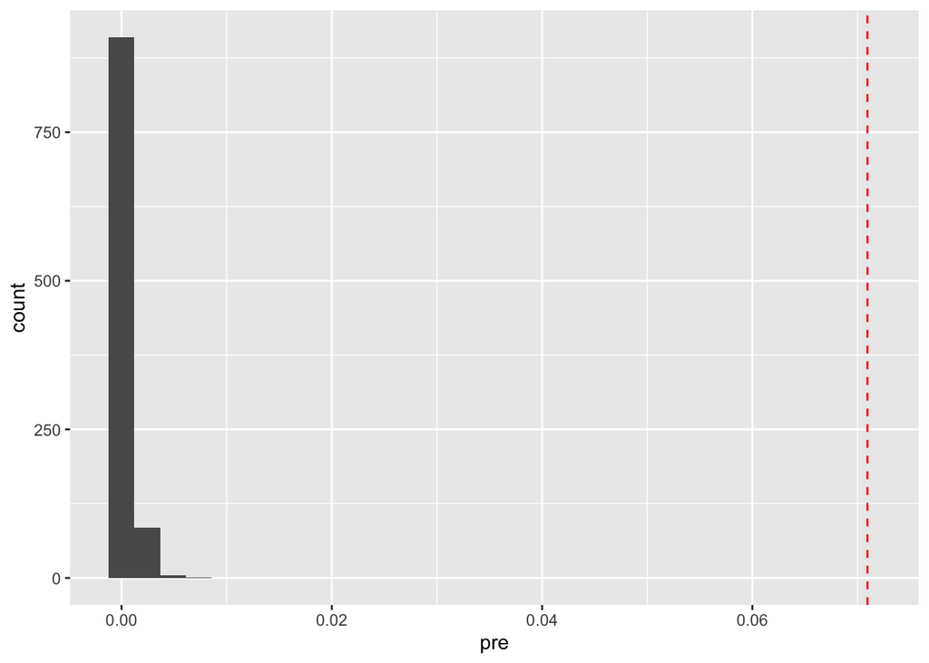

```r
ggplot(null_sims,
       aes(x = pre)) +
  geom_histogram() +
  geom_vline(xintercept = observed_pre,
             linetype = "dashed",
             color = "red")
```